# J2 Unbiased 50 um Neighborhood Niche Resolution

Author

Codex

Published

October 8, 2026

```r
library(data.table)
library(knitr)

script_dir <- dirname(knitr::current_input(dir = TRUE))
project_dir <- normalizePath(file.path(script_dir, ".."), mustWork = TRUE)
result_dir <- file.path(
  project_dir,
  "results/reanalysis/J2_UNBIASED_NICHE_RESOLUTION_20261008_110522"
)

input_audit <- fread(file.path(result_dir, "00_J2_INPUT_AUDIT.tsv"))
neighborhood_audit <- fread(file.path(result_dir, "01_J2_NEIGHBORHOOD_AUDIT.tsv"))
recommendation <- fread(file.path(result_dir, "04_J2_AUDITED_K_RECOMMENDATION.tsv"))
annotations <- fread(file.path(result_dir, "11_J2_PRIMARYK_CONSERVATIVE_ANNOTATIONS.tsv"))
cross_patient <- fread(file.path(result_dir, "09_J2_PRIMARYK_CROSS_PATIENT_ENRICHMENT.tsv"))
final_audit <- fread(file.path(result_dir, "13_J2_FINAL_AUDIT.tsv"))

primary <- recommendation[role == "primary"][1]
lower <- recommendation[role == "lower-resolution comparator"][1]
higher <- recommendation[role == "higher-resolution sensitivity"][1]

audit_value <- function(item_name) {
  final_audit[item == item_name, value][[1]]
}
```

## Scope and provenance

This report documents the completed, chip-specific discovery analysis for Y40105J2. It used frozen Reference18 continuous weights for Bin50 with UMI >= 50, the official 50 um radius neighborhood definition, native VoltRon CLR features, and independent K-means fits for K=3–12. The center Bin was excluded from its own neighborhood, matching the audited L3 framework.

- UMI-eligible Bin50: 58,840
- Neighborhood-evaluable Bin50: 58,772
- Patients: 7 (HC=2;IPF=2;SSc-ILD=3)
- Reference18 states: 18
- Radius: 50 um
- Random seeds per K: 20

Frozen lymphoid aggregate labels were not read. Disease labels were retained only as metadata and were not used for neighborhood construction, clustering, K selection, or niche annotation. This analysis did not perform disease-significance testing, DEG, GSEA, pathway analysis, or cell-cell communication analysis.

```r
kable(
  input_audit[, .(
    patient_id,
    disease,
    total_umi50_bin_n,
    evaluable_radius50_bin_n,
    roi_n,
    missing_coordinate_n,
    missing_reference18_weight_n
  )],
  caption = "J2 patient-level input audit"
)
```

J2 patient-level input audit

| patient_id | disease | total_umi50_bin_n | evaluable_radius50_bin_n | roi_n | missing_coordinate_n | missing_reference18_weight_n |
| --- | --- | --- | --- | --- | --- | --- |
| HC/NL-55 | HC | 10250 | 10250 | 1 | 0 | 0 |
| HC/NL-63 | HC | 5441 | 5441 | 1 | 0 | 0 |
| IPF/FO23-1-03100 | IPF | 8373 | 8373 | 1 | 0 | 0 |
| IPF/FO23-1-09473 | IPF | 2663 | 2663 | 1 | 0 | 0 |
| SSC/23-105334B1 | SSc-ILD | 20939 | 20874 | 1 | 0 | 0 |
| SSC/FO20-I-08293B1 | SSc-ILD | 3947 | 3944 | 1 | 0 | 0 |
| SSC/FO21-1-01756B1 | SSc-ILD | 7227 | 7227 | 1 | 0 | 0 |

```r
kable(neighborhood_audit, caption = "Audited 50 um neighborhood definition")
```

Audited 50 um neighborhood definition

| chip | radius_um | center_bin_included | total_umi50_bin_n | evaluable_bin_n | zero_neighbor_bin_n | edge_n | patient_n | roi_n | cross_patient_or_roi_edge_n | niche_aggregation | clr_method | object_source | official_neighbor_cap_truncated_bin_n | tissue_component_boundary_enforced | empty_neighborhood_handling | reconstruction_check |
| --- | --- | --- | --- | --- | --- | --- | --- | --- | --- | --- | --- | --- | --- | --- | --- | --- |
| Y40105J2 | 50 | FALSE | 58840 | 58772 | 68 | 325776 | 7 | 7 | 0 | sum of neighboring Bin50 Reference18 weights; center excluded | VoltRon normalizeData(method=‘CLR’); no pseudocount; structural zeros retained | /mnt/d/bb/博士课题组资料/新建文件夹/自己课题相关/Lung ST/codex agent/stereo_seq/stereo_seq/results/reanalysis/J2_UNBIASED_NICHE_RESOLUTION_20261008_110522/14_VOLTRON_OBJECT_RADIUS50_CLR.rds | 0 | FALSE | 68 Bins marked not evaluable; not represented as all-zero profiles | Rebuilt from frozen J2 input because saved object was unavailable; edge count, zero-neighbor count and cross-block count match the prior official audit |

## K=3–12 resolution audit

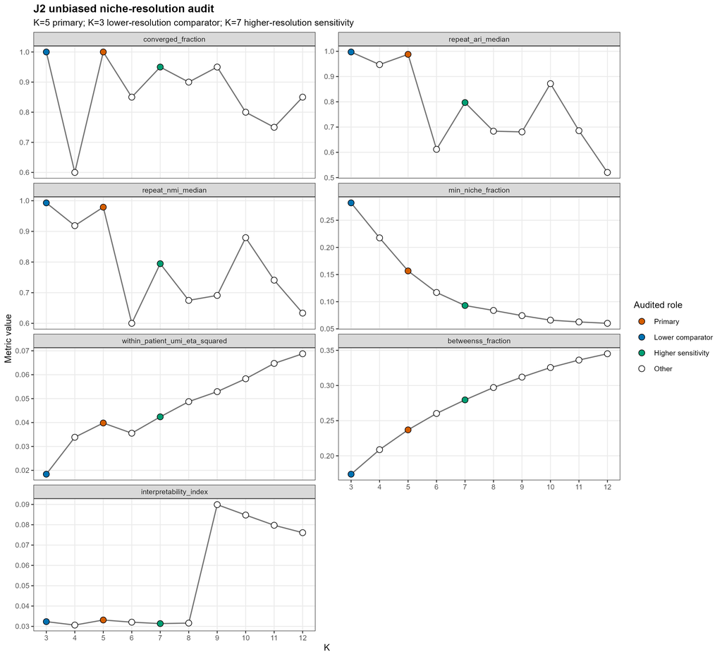

```r
kable(
  recommendation[, .(
    k,
    role,
    converged_seed_n,
    seed_fit_n,
    repeat_ari_median,
    repeat_nmi_median,
    betweenss_fraction,
    min_niche_fraction,
    min_patient_coverage_n,
    below_one_percent_niche_n,
    single_patient_niche_n,
    within_patient_umi_eta_squared,
    audited_reason
  )],
  digits = 3,
  caption = "Audited J2 resolution recommendation and comparators"
)
```

Audited J2 resolution recommendation and comparators

| k | role | converged_seed_n | seed_fit_n | repeat_ari_median | repeat_nmi_median | betweenss_fraction | min_niche_fraction | min_patient_coverage_n | below_one_percent_niche_n | single_patient_niche_n | within_patient_umi_eta_squared | audited_reason |
| --- | --- | --- | --- | --- | --- | --- | --- | --- | --- | --- | --- | --- |
| 5 | primary | 20 | 20 | 0.988 | 0.979 | 0.237 | 0.157 | 7 | 0 | 0 | 0.040 | K=5 retains 20/20 convergence, median ARI 0.988 and median NMI 0.979, all niches cover all seven patients, the smallest niche is 15.7%, within-patient UMI eta-squared is 0.040, and Reference18 composi… |
| 3 | lower-resolution comparator | 20 | 20 | 0.997 | 0.993 | 0.174 | 0.282 | 7 | 0 | 0 | 0.018 | K=3 is the automated-score optimum and highly stable (20/20 converged; median ARI 0.997), but combines several broad composition gradients and is therefore retained as an under-resolution comparator |
| 7 | higher-resolution sensitivity | 19 | 20 | 0.797 | 0.795 | 0.280 | 0.093 | 7 | 0 | 0 | 0.042 | K=7 is the nearest eligible higher-resolution sensitivity with 19/20 convergence, all-patient coverage, no niche below 1%, minimum niche fraction 9.3%, and lower UMI association than K>=8; its median … |

K=5 is the audited primary resolution. It converged in 20/20 fits, had median pairwise ARI 0.988, covered all seven patients in every niche, and had a smallest niche fraction of 15.7%. K=3 is retained as an under-resolution comparator; K=7 is retained only as a higher-resolution sensitivity analysis. Disease separation was not a K-selection criterion.

## Primary-K Reference18 composition

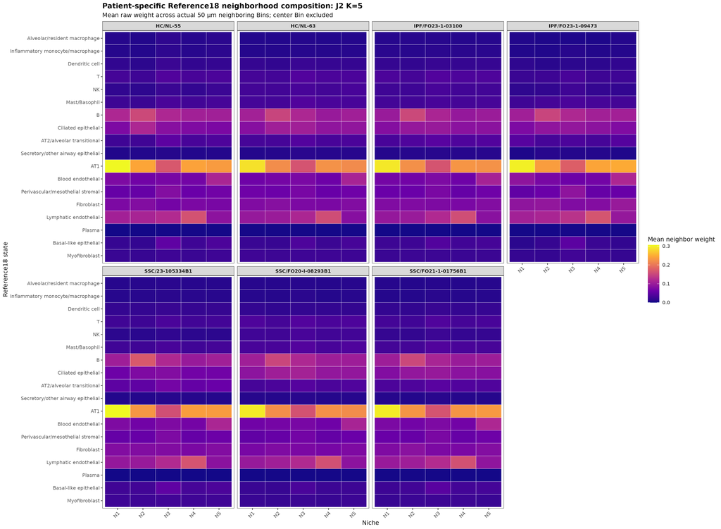

```r
kable(
  annotations[, .(
    niche,
    proposed_annotation,
    core_positive_states,
    positive_patient_consistency,
    umi_robust,
    any_state_single_patient_driven,
    core_state_single_patient_driven,
    confidence,
    interpretation_limit
  )],
  caption = "Conservative primary-K niche annotations"
)
```

Conservative primary-K niche annotations

| niche | proposed_annotation | core_positive_states | positive_patient_consistency | umi_robust | any_state_single_patient_driven | core_state_single_patient_driven | confidence | interpretation_limit |
| --- | --- | --- | --- | --- | --- | --- | --- | --- |
| N1 | alveolar-associated mixed niche | AT1 | 7/7 or greater | TRUE | FALSE | FALSE | moderate-high | Relative Reference18 neighborhood composition; mixed Bin50 neighborhoods; not a pure cell type, independent validation, or disease result |
| N2 | B-enriched mixed niche | B; Ciliated epithelial; Fibroblast; Plasma | 6/7 or greater | TRUE | TRUE | FALSE | moderate-high | Relative Reference18 neighborhood composition; mixed Bin50 neighborhoods; not a pure cell type, independent validation, or disease result |
| N3 | airway-associated mixed niche | Basal-like epithelial; Perivascular/mesothelial stromal; Ciliated epithelial; T; AT2/alveolar transitional; Lymphatic endothelial; Mast/Basophil; NK; Dendritic cell; Myofibroblast; Secretory/other air… | 6/7 or greater | TRUE | TRUE | FALSE | moderate-high | Relative Reference18 neighborhood composition; mixed Bin50 neighborhoods; not a pure cell type, independent validation, or disease result |
| N4 | endothelial-associated mixed niche | Lymphatic endothelial | 7/7 or greater | TRUE | FALSE | FALSE | moderate-high | Relative Reference18 neighborhood composition; mixed Bin50 neighborhoods; not a pure cell type, independent validation, or disease result |
| N5 | endothelial-associated mixed niche | Blood endothelial; Fibroblast; Perivascular/mesothelial stromal; T; Dendritic cell; Alveolar/resident macrophage; Inflammatory monocyte/macrophage | 6/7 or greater | TRUE | TRUE | FALSE | moderate-high | Relative Reference18 neighborhood composition; mixed Bin50 neighborhoods; not a pure cell type, independent validation, or disease result |

The five niches represent mixed neighborhood-composition gradients rather than pure cell types. The most reproducible axes include AT1 enrichment in N1, B enrichment in N2, lymphatic-endothelial enrichment in N4, and blood-endothelial enrichment in N5. N3 has a broader mixed airway/stromal/immune profile. No core state was classified as single-patient-driven.

## Cross-patient consistency

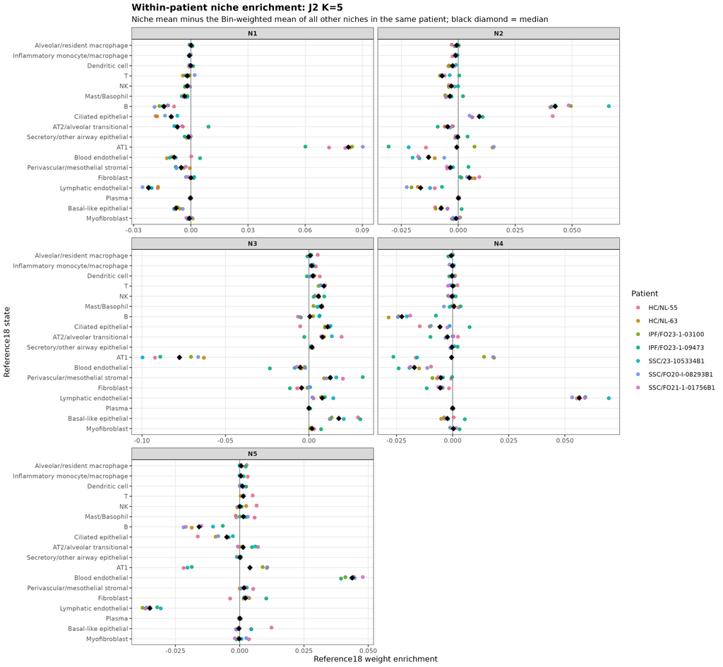

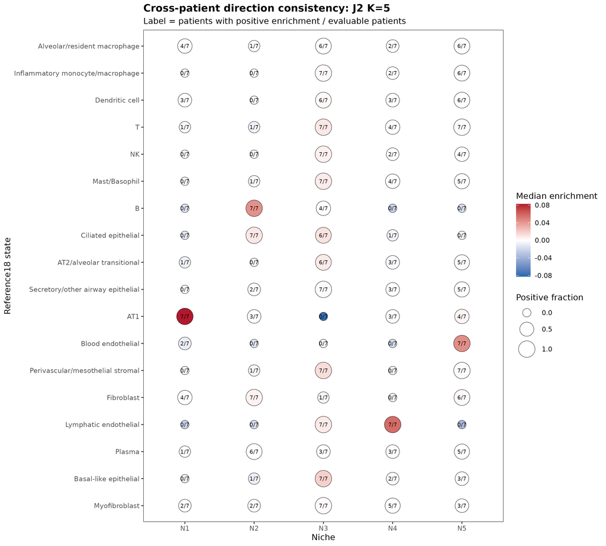

```r
core_states <- unique(unlist(strsplit(
  paste(annotations$core_positive_states, collapse = ";"),
  ";\\s*"
)))
core_summary <- cross_patient[
  reference18_state %in% core_states & positive_patient_n >= 6,
  .(
    niche,
    reference18_state,
    median_enrichment,
    positive_patient_n,
    evaluable_patient_count,
    loo_direction_stable,
    single_patient_driven
  )
]
kable(
  core_summary[order(niche, -median_enrichment)],
  digits = 4,
  caption = "Cross-patient consistency for recurrent core-state enrichments"
)
```

Cross-patient consistency for recurrent core-state enrichments

| niche | reference18_state | median_enrichment | positive_patient_n | evaluable_patient_count | loo_direction_stable | single_patient_driven |
| --- | --- | --- | --- | --- | --- | --- |
| N1 | AT1 | 0.0827 | 7 | 7 | TRUE | FALSE |
| N2 | B | 0.0426 | 7 | 7 | TRUE | FALSE |
| N2 | Ciliated epithelial | 0.0092 | 7 | 7 | TRUE | FALSE |
| N2 | Fibroblast | 0.0049 | 7 | 7 | TRUE | FALSE |
| N2 | Plasma | 0.0001 | 6 | 7 | TRUE | FALSE |
| N3 | Basal-like epithelial | 0.0179 | 7 | 7 | TRUE | FALSE |
| N3 | Perivascular/mesothelial stromal | 0.0128 | 7 | 7 | TRUE | FALSE |
| N3 | Ciliated epithelial | 0.0112 | 6 | 7 | TRUE | FALSE |
| N3 | T | 0.0090 | 7 | 7 | TRUE | FALSE |
| N3 | AT2/alveolar transitional | 0.0082 | 6 | 7 | TRUE | FALSE |
| N3 | Lymphatic endothelial | 0.0080 | 7 | 7 | TRUE | FALSE |
| N3 | Mast/Basophil | 0.0075 | 7 | 7 | TRUE | FALSE |
| N3 | NK | 0.0057 | 7 | 7 | TRUE | FALSE |
| N3 | Dendritic cell | 0.0024 | 6 | 7 | TRUE | FALSE |
| N3 | Myofibroblast | 0.0018 | 7 | 7 | TRUE | FALSE |
| N3 | Secretory/other airway epithelial | 0.0018 | 7 | 7 | TRUE | FALSE |
| N3 | Inflammatory monocyte/macrophage | 0.0017 | 7 | 7 | TRUE | FALSE |
| N3 | Alveolar/resident macrophage | 0.0008 | 6 | 7 | TRUE | FALSE |
| N4 | Lymphatic endothelial | 0.0564 | 7 | 7 | TRUE | FALSE |
| N5 | Blood endothelial | 0.0438 | 7 | 7 | TRUE | FALSE |
| N5 | Fibroblast | 0.0022 | 6 | 7 | TRUE | FALSE |
| N5 | Perivascular/mesothelial stromal | 0.0017 | 7 | 7 | TRUE | FALSE |
| N5 | T | 0.0014 | 7 | 7 | TRUE | FALSE |
| N5 | Dendritic cell | 0.0011 | 6 | 7 | TRUE | FALSE |
| N5 | Alveolar/resident macrophage | 0.0006 | 6 | 7 | TRUE | FALSE |
| N5 | Inflammatory monocyte/macrophage | 0.0004 | 6 | 7 | TRUE | FALSE |

`any_state_single_patient_driven` and `core_state_single_patient_driven` are reported separately so that a weak peripheral state cannot invalidate a stable core composition axis.

## UMI sensitivity

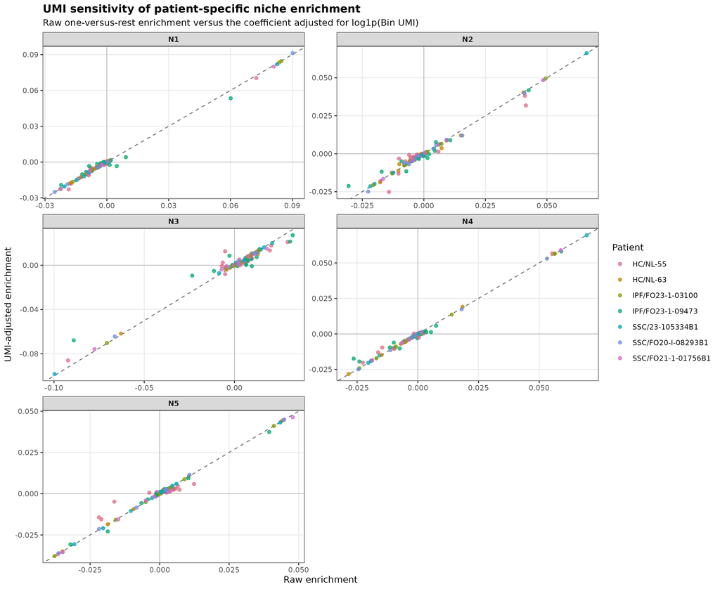

The core directions were retained after adjustment for scaled log1p(Bin UMI) and within-patient UMI-quantile stratification. These checks assess sensitivity; they do not establish that UMI effects have been completely removed.

## Interpretation boundaries

J2 independently recapitulated broad B-enriched, alveolar-associated, endothelial-associated, airway-associated, and stromal/immune mixed themes. This is a blind descriptive comparison with L3, not a formal cross-chip alignment. Niche numbers are chip-specific and cannot be mapped across chips by number.

The analysis supports proceeding to a separate J2 spatial architecture audit and then an independently fitted Y40102K8 analysis. Cross-chip consensus and biological pathway analyses remain outside this report.

## Output validation

```r
kable(final_audit, caption = "Final J2 output audit")
```

Final J2 output audit

| item | value | passed |
| --- | --- | --- |
| chip | Y40105J2 | TRUE |
| input_path | results/reanalysis/REFERENCE18_UMI50_VOLTRON_PER_CHIP_NICHE_20261005_153036/J2/01_FROZEN_REFERENCE18_INPUT.tsv.gz | TRUE |
| Reference18_source | frozen Reference18 continuous weights | TRUE |
| Bin50_threshold | UMI >= 50 | TRUE |
| total_umi50_bin_n | 58840 | TRUE |
| evaluable_bin_n | 58772 | TRUE |
| patient_n | 7 | TRUE |
| disease_counts | HC=2;IPF=2;SSc-ILD=3 | TRUE |
| neighborhood_radius_um | 50 | TRUE |
| center_bin_included | FALSE | TRUE |
| CLR_method | VoltRon normalizeData(method=‘CLR’); no pseudocount; structural zeros retained | TRUE |
| K_range | 3-12 | TRUE |
| seeds_per_K | 20 | TRUE |
| selected_primary_K | 5 | TRUE |
| lower_comparator | 3 | TRUE |
| higher_comparator | 7 | TRUE |
| disease_used_in_clustering | FALSE | TRUE |
| frozen_aggregate_used | FALSE | TRUE |
| disease_significance | FALSE | TRUE |
| DEG | FALSE | TRUE |
| GSEA | FALSE | TRUE |
| pathway | FALSE | TRUE |
| cell_cell_communication | FALSE | TRUE |
| output::00_J2_INPUT_AUDIT.tsv | D:STagent_seq_seq_UNBIASED_NICHE_RESOLUTION_20261008_110522/00_J2_INPUT_AUDIT.tsv | TRUE |
| output::01_J2_NEIGHBORHOOD_AUDIT.tsv | D:STagent_seq_seq_UNBIASED_NICHE_RESOLUTION_20261008_110522/01_J2_NEIGHBORHOOD_AUDIT.tsv | TRUE |
| output::02_J2_ALL_K_SEED_FIT_AUDIT.tsv.gz | D:STagent_seq_seq_UNBIASED_NICHE_RESOLUTION_20261008_110522/02_J2_ALL_K_SEED_FIT_AUDIT.tsv.gz | TRUE |
| output::03_J2_K3_K12_RESOLUTION_SUMMARY.tsv | D:STagent_seq_seq_UNBIASED_NICHE_RESOLUTION_20261008_110522/03_J2_K3_K12_RESOLUTION_SUMMARY.tsv | TRUE |
| output::04_J2_AUDITED_K_RECOMMENDATION.tsv | D:STagent_seq_seq_UNBIASED_NICHE_RESOLUTION_20261008_110522/04_J2_AUDITED_K_RECOMMENDATION.tsv | TRUE |
| output::05_J2_K_RECOMMENDATION_ZH.md | D:STagent_seq_seq_UNBIASED_NICHE_RESOLUTION_20261008_110522/05_J2_K_RECOMMENDATION_ZH.md | TRUE |
| output::06_J2_PRIMARYK_REFERENCE18_COMPOSITION.tsv | D:STagent_seq_seq_UNBIASED_NICHE_RESOLUTION_20261008_110522/06_J2_PRIMARYK_REFERENCE18_COMPOSITION.tsv | TRUE |
| output::07_J2_PRIMARYK_PATIENT_NICHE_COMPOSITION.tsv | D:STagent_seq_seq_UNBIASED_NICHE_RESOLUTION_20261008_110522/07_J2_PRIMARYK_PATIENT_NICHE_COMPOSITION.tsv | TRUE |
| output::08_J2_PRIMARYK_PATIENT_NICHE_ENRICHMENT.tsv | D:STagent_seq_seq_UNBIASED_NICHE_RESOLUTION_20261008_110522/08_J2_PRIMARYK_PATIENT_NICHE_ENRICHMENT.tsv | TRUE |
| output::09_J2_PRIMARYK_CROSS_PATIENT_ENRICHMENT.tsv | D:STagent_seq_seq_UNBIASED_NICHE_RESOLUTION_20261008_110522/09_J2_PRIMARYK_CROSS_PATIENT_ENRICHMENT.tsv | TRUE |
| output::10_J2_PRIMARYK_UMI_SENSITIVITY.tsv | D:STagent_seq_seq_UNBIASED_NICHE_RESOLUTION_20261008_110522/10_J2_PRIMARYK_UMI_SENSITIVITY.tsv | TRUE |
| output::11_J2_PRIMARYK_CONSERVATIVE_ANNOTATIONS.tsv | D:STagent_seq_seq_UNBIASED_NICHE_RESOLUTION_20261008_110522/11_J2_PRIMARYK_CONSERVATIVE_ANNOTATIONS.tsv | TRUE |
| output::12_J2_KEY_FINDINGS_ZH.md | D:STagent_seq_seq_UNBIASED_NICHE_RESOLUTION_20261008_110522/12_J2_KEY_FINDINGS_ZH.md | TRUE |
| output::figures/01_J2_K_RESOLUTION_AUDIT_EN.pdf | D:STagent_seq_seq_UNBIASED_NICHE_RESOLUTION_20261008_110522/figures/01_J2_K_RESOLUTION_AUDIT_EN.pdf | TRUE |
| output::figures/01_J2_K_RESOLUTION_AUDIT_EN.png | D:STagent_seq_seq_UNBIASED_NICHE_RESOLUTION_20261008_110522/figures/01_J2_K_RESOLUTION_AUDIT_EN.png | TRUE |
| output::figures/02_J2_PRIMARYK_REFERENCE18_COMPOSITION_EN.pdf | D:STagent_seq_seq_UNBIASED_NICHE_RESOLUTION_20261008_110522/figures/02_J2_PRIMARYK_REFERENCE18_COMPOSITION_EN.pdf | TRUE |
| output::figures/02_J2_PRIMARYK_REFERENCE18_COMPOSITION_EN.png | D:STagent_seq_seq_UNBIASED_NICHE_RESOLUTION_20261008_110522/figures/02_J2_PRIMARYK_REFERENCE18_COMPOSITION_EN.png | TRUE |
| output::figures/03_J2_PRIMARYK_PATIENT_WISE_ENRICHMENT_EN.pdf | D:STagent_seq_seq_UNBIASED_NICHE_RESOLUTION_20261008_110522/figures/03_J2_PRIMARYK_PATIENT_WISE_ENRICHMENT_EN.pdf | TRUE |
| output::figures/03_J2_PRIMARYK_PATIENT_WISE_ENRICHMENT_EN.png | D:STagent_seq_seq_UNBIASED_NICHE_RESOLUTION_20261008_110522/figures/03_J2_PRIMARYK_PATIENT_WISE_ENRICHMENT_EN.png | TRUE |
| output::figures/04_J2_PRIMARYK_CROSS_PATIENT_DIRECTION_CONSISTENCY_EN.pdf | D:STagent_seq_seq_UNBIASED_NICHE_RESOLUTION_20261008_110522/figures/04_J2_PRIMARYK_CROSS_PATIENT_DIRECTION_CONSISTENCY_EN.pdf | TRUE |
| output::figures/04_J2_PRIMARYK_CROSS_PATIENT_DIRECTION_CONSISTENCY_EN.png | D:STagent_seq_seq_UNBIASED_NICHE_RESOLUTION_20261008_110522/figures/04_J2_PRIMARYK_CROSS_PATIENT_DIRECTION_CONSISTENCY_EN.png | TRUE |
| output::figures/05_J2_PRIMARYK_UMI_SENSITIVITY_EN.pdf | D:STagent_seq_seq_UNBIASED_NICHE_RESOLUTION_20261008_110522/figures/05_J2_PRIMARYK_UMI_SENSITIVITY_EN.pdf | TRUE |
| output::figures/05_J2_PRIMARYK_UMI_SENSITIVITY_EN.png | D:STagent_seq_seq_UNBIASED_NICHE_RESOLUTION_20261008_110522/figures/05_J2_PRIMARYK_UMI_SENSITIVITY_EN.png | TRUE |

All saved audit rows passed. The analysis directory also contains seed-level fit diagnostics, all-K assignments, patient-specific composition tables, and complete session information.

[session information not shown]